# Abridged Classics_Brief Summaries of Books You Were Supposed to Read but Probably Didn't.Atkinson2018

Contents

[figure not shown]

[figure not shown]

Dedication

To Dylan, Jacob, and Madz

Epigraph

“Classic.” A book people praise and don’t read.

– MARK TWAIN

Contents

*Cover*

*Title Page*

*Dedication*

*Epigraph*

Ulysses

Moby Dick

War and Peace

Beowulf

Oliver Twist

Walden

Macbeth

Brave New World

In Search of Lost Time

The Sun also Rises

Naked Lunch

The Picture of Dorian Gray

The Brothers Karamazov

To Kill a Mockingbird

The Catcher in the Rye

The Faerie Queen

Animal Farm

Pride and Prejudice

The Odyssey

The Iliad

Don Quixote

Crime and Punishment

Catch-22

Heart of Darkness

The Republic

Wuthering Heights

Robinson Crusoe

The Pearl

The Grapes of Wrath

A Farewell to Arms

The Rime of the Ancient Mariner

Othello

On the Road

The Canterbury Tales

The Divine Comedy: Inferno

Peter Pan

Treasure Island

Frankenstein

Gulliver’s Travels

1984

Great Expectations

The Adventures of Huckleberry Finn

The Aeneid

The Return of the Native

Sense and Sensibility

The Trial

Emma

The Lord of the Rings Trilogy

The Great Gatsby

King Lear

Ivanov

The Crucible

Ethan Frome

Anna Karenina

Jane Eyre

Twelfth Night

The Da Vinci Code

Romeo and Juliet

The Mysteries of Udolpho

The Scarlet Letter

Little Women

The Pilgrim’s Progress

Madame Bovary

The Stranger

To the Lighthouse

The Metamorphosis

Waiting for Godot

Hamlet

Of Mice and Men

Lolita

The Fountainhead

Oedipus Rex

The Handmaid’s Tale

A Portrait of the Artist as a Young Man

The Wonderful Wizard of Oz

Richard III

Paradise Lost

The Lion, the Witch and the Wardrobe

The Hunchback of Notre Dame

The Count of Monte Cristo

The Waste Land

The Red Badge of Courage

Tarzan of the Apes

The Bell Jar

Moll Flanders

The Three Musketeers

Charlotte’s Web

Julius Caesar

Candide

The Prince

The Jungle Book

The Raven

Lord of the Flies

Anne of Green Gables

The Old Man and the Sea

Tom Jones

Mrs. Dalloway

Fahrenheit 451

Tropic of Cancer

Life of Pi

The Bible

*Acknowledgments*

*Index by Book*

*Index by Author*

*About the Author*

*Copyright*

*About the Publisher*

Ulysses

James Joyce

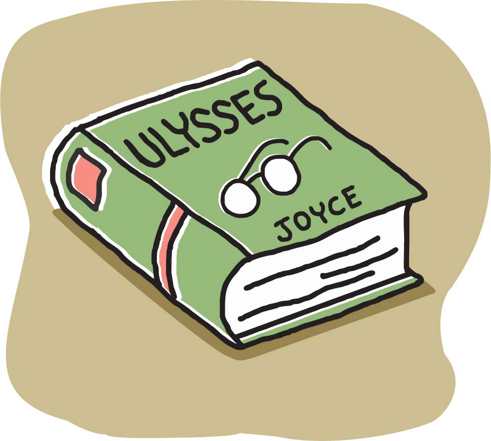

Dublin, something, something, something, run-on sentence.

Moby Dick

Herman Melville

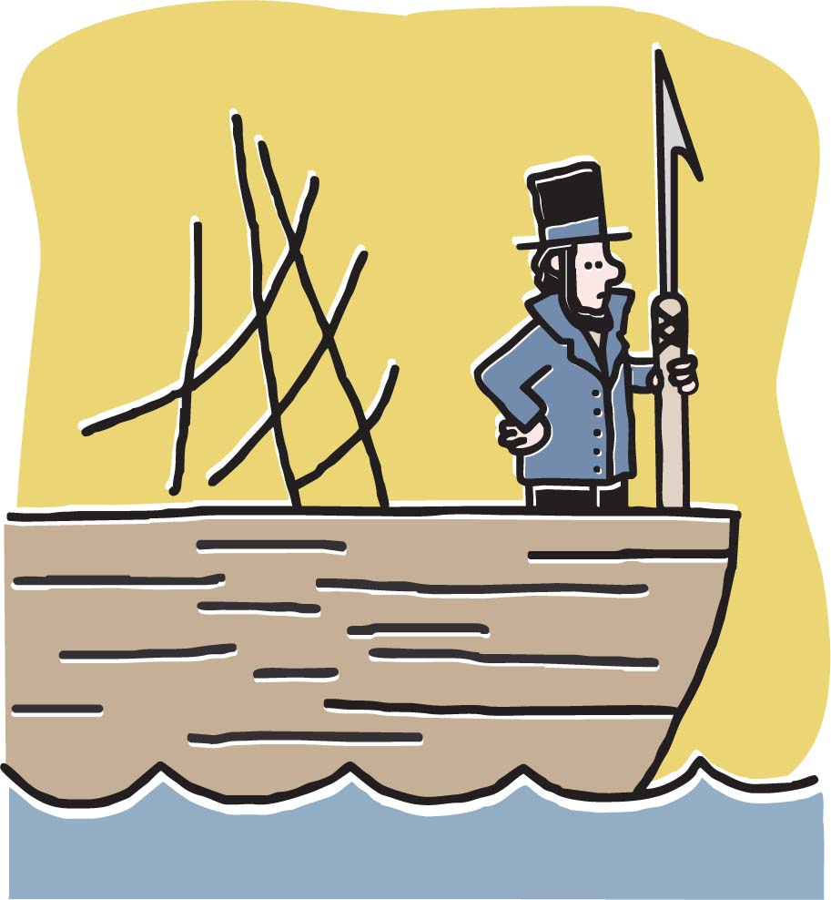

Man vs. whale.

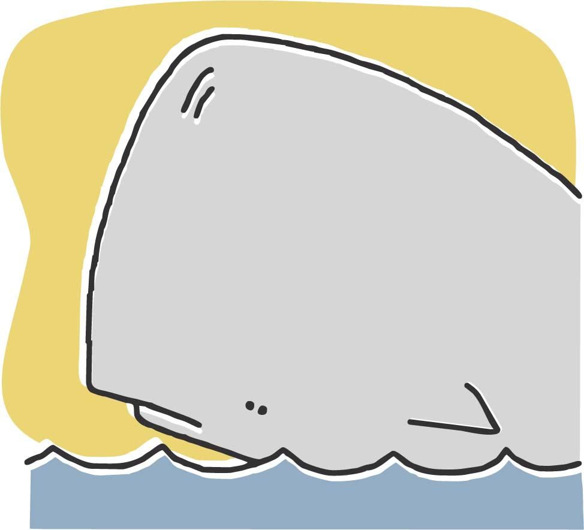

Whale wins.

War and Peace

Leo Tolstoy

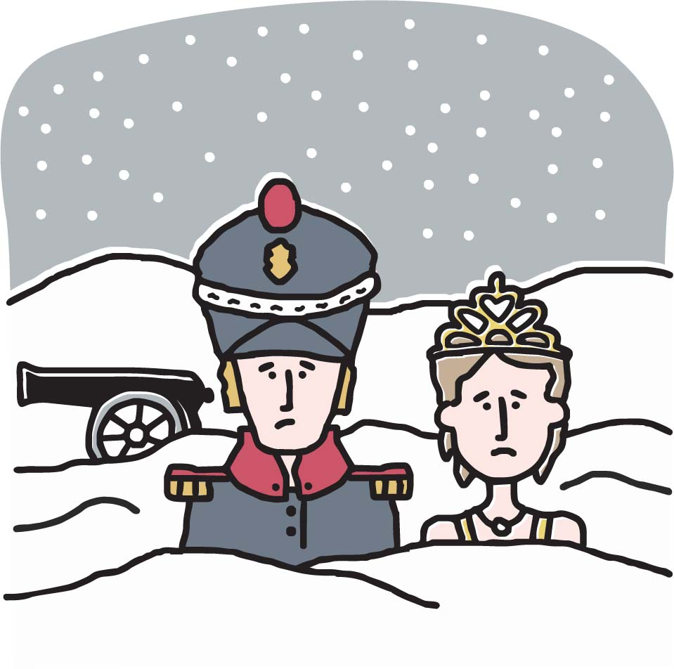

Everyone is sad.

It snows.

Beowulf

Unknown

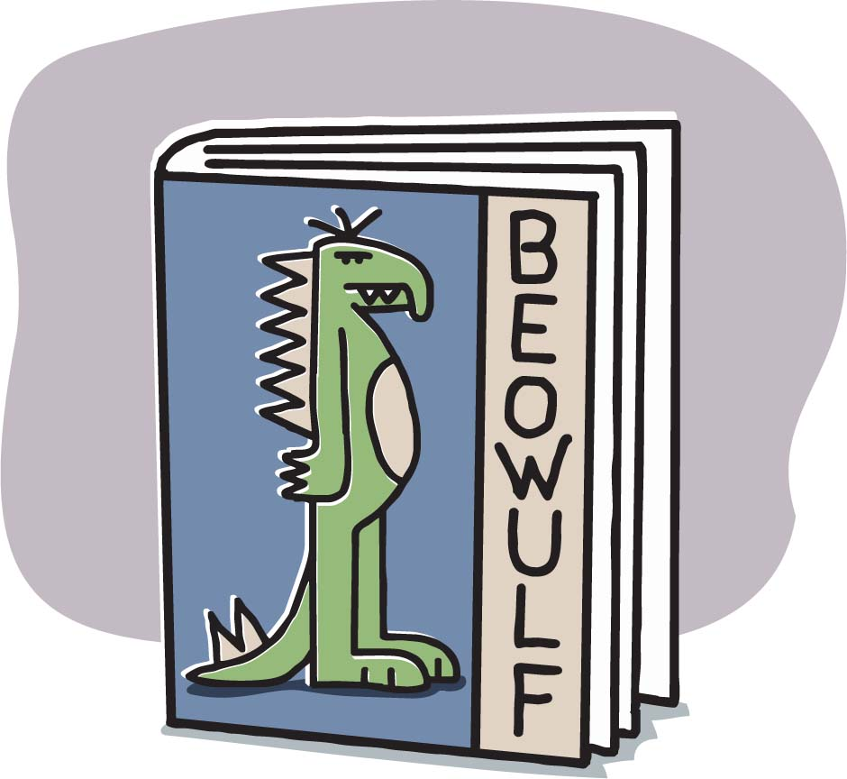

Hero kills monster.

Blah, blah, blah.

Dragon kills hero.

Oliver Twist

Charles Dickens

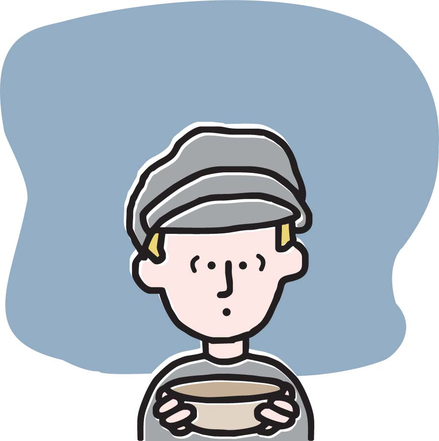

Orphan wants more.

He doesn’t get it.

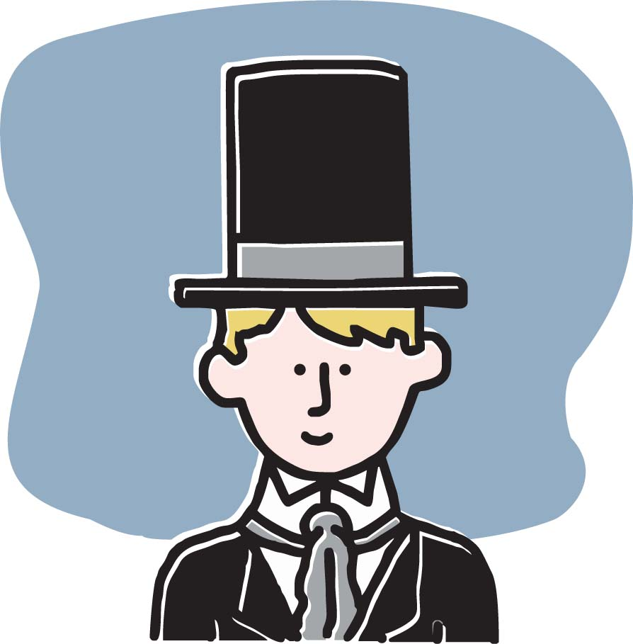

Wait, yes he does.

Walden

Henry David Thoreau

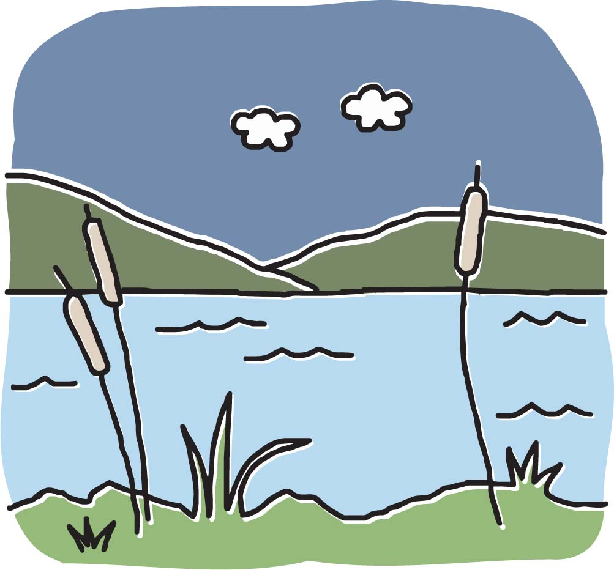

Man sits outside for two years.

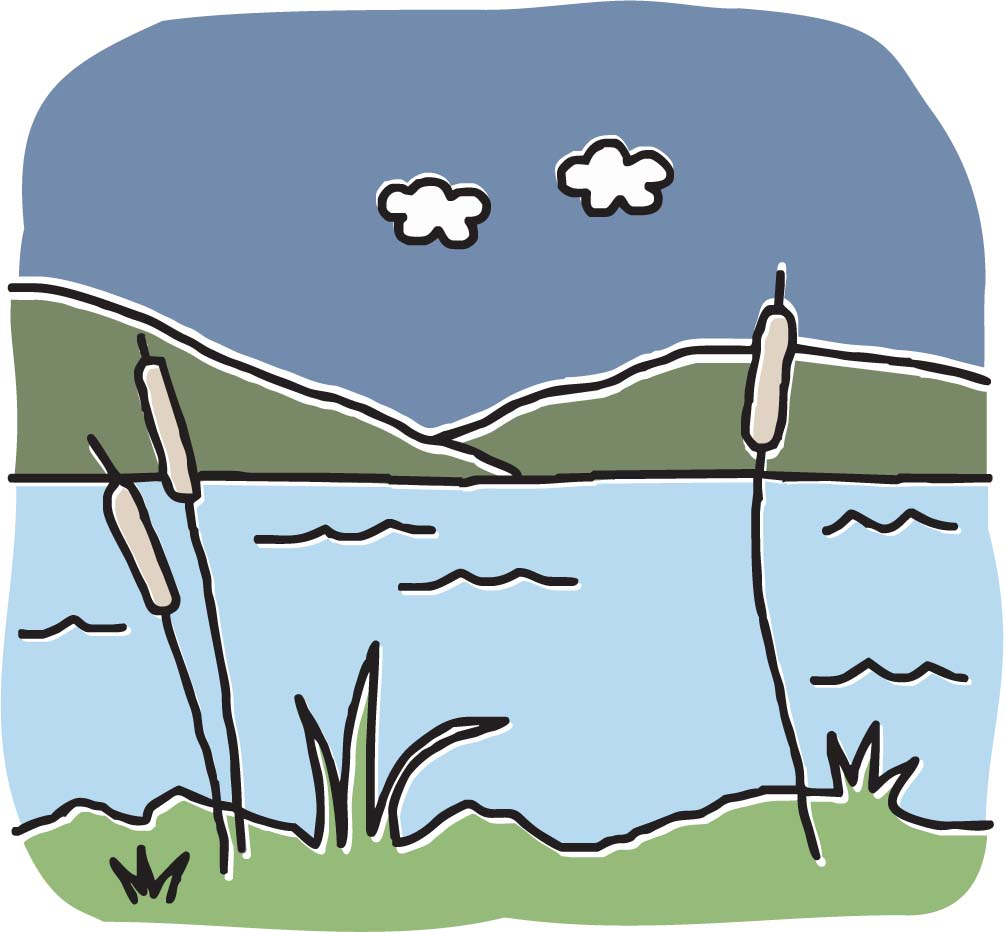

Nothing happens.

Macbeth

William Shakespeare

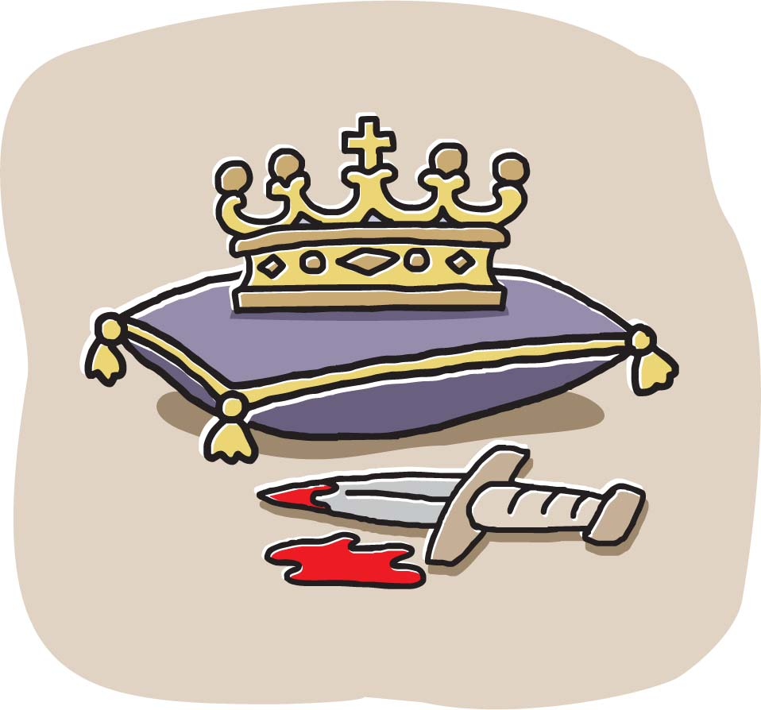

Old ladies convince a guy to ruin Scotland.

Brave New World

Aldous Huxley

[figure not shown]

Everyone is high.

Nothing gets done.

In Search of Lost Time

Marcel Proust

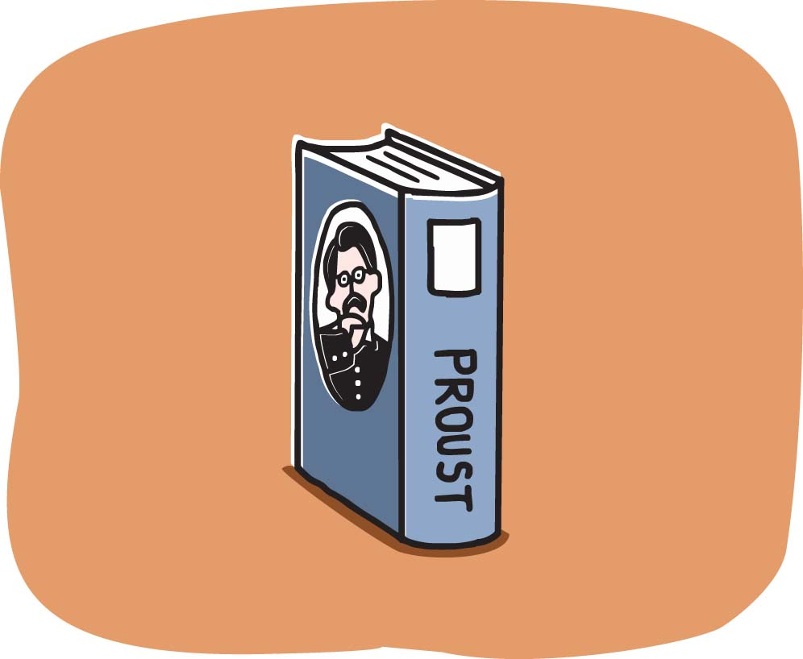

Smell of cake reminds a guy of stuff.

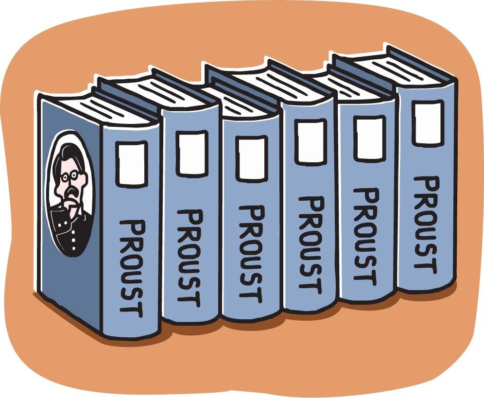

Four thousand pages of stuff.

The Sun also Rises

Ernest Hemingway

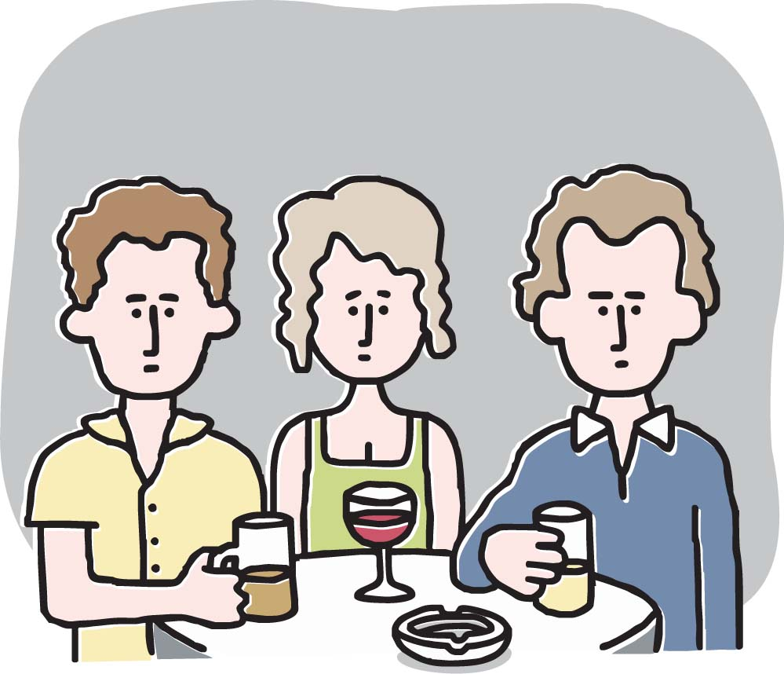

Lost generation gets drunk.

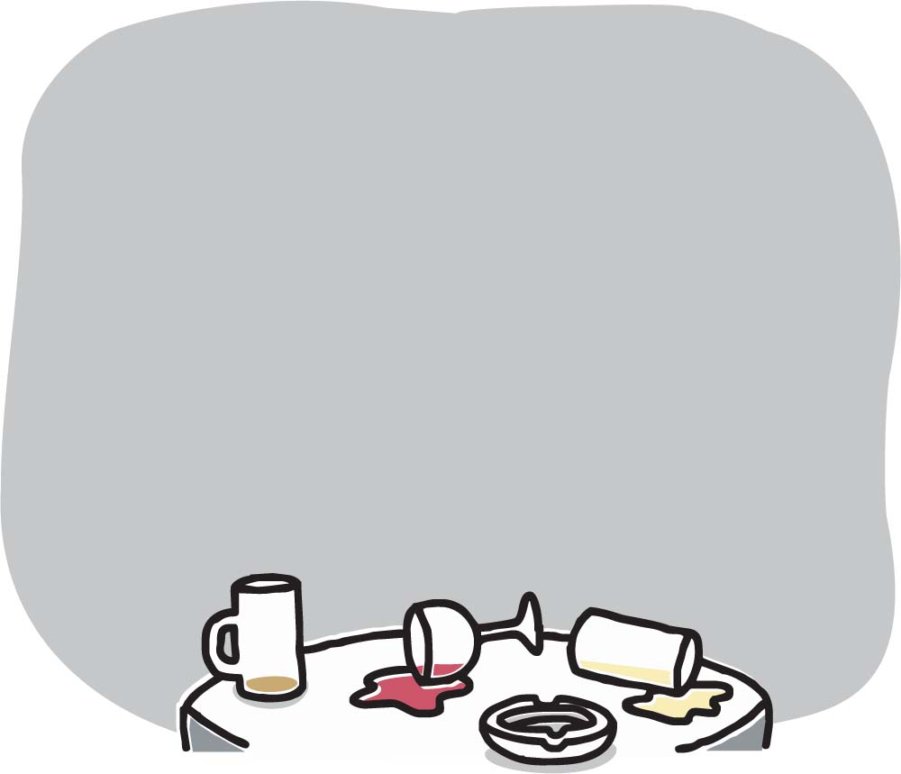

They’re still lost.

Naked Lunch

William S. Burroughs

[figure not shown]

Heroin can really mess you up.

Anyway, here’s an orgy.

The Picture of Dorian Gray

Oscar Wilde

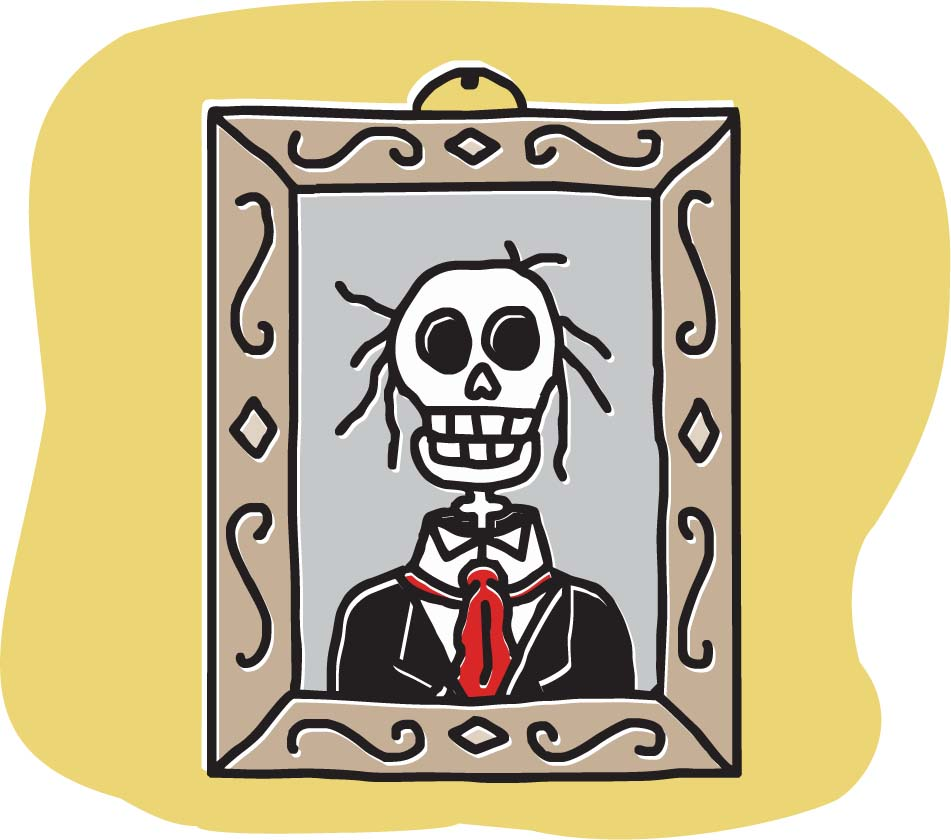

If looks could kill, they probably will.

The Brothers Karamazov

Fyodor Dostoyevsky

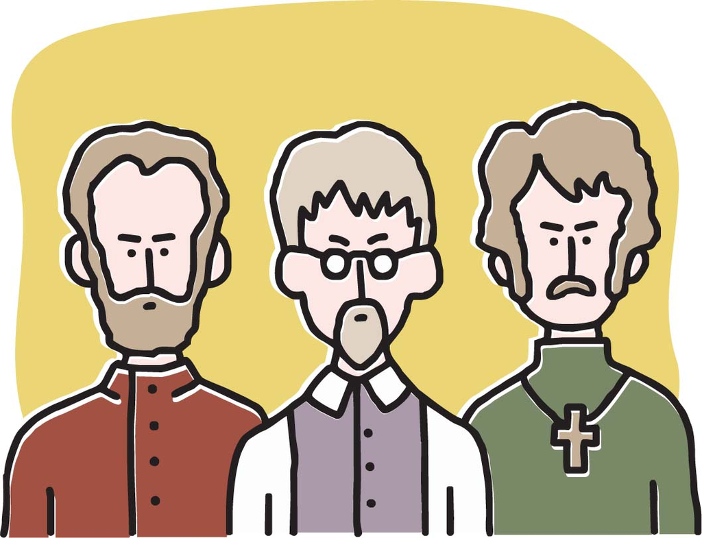

Brothers are very contentious, like their father.

[figure not shown]

Also Russia.

To Kill a Mockingbird

Harper Lee

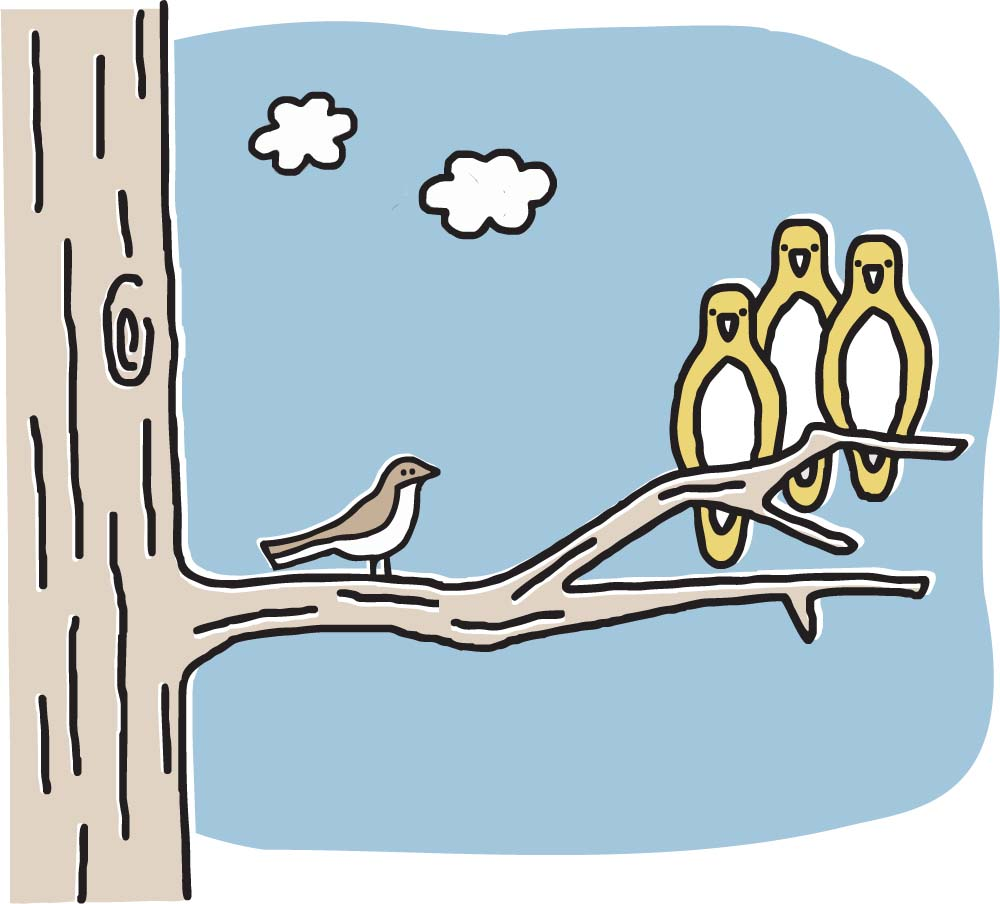

Kids don’t understand racism.

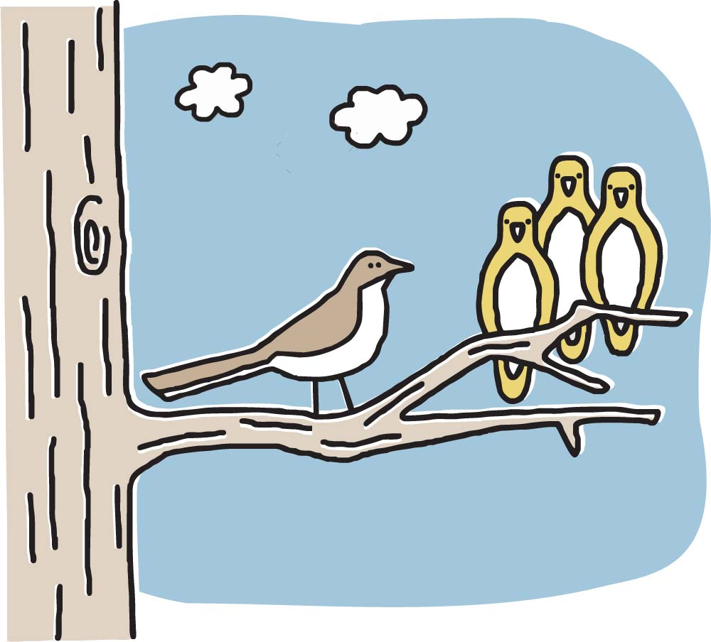

Adults don’t either.

The Catcher in the Rye

J. D. Salinger

[figure not shown]

Moody teen complains a lot.

He has a red hat.

The Faerie Queen

Edmund Spenser

[figure not shown]

“How Not to Be a Jerk” for knights.

Animal Farm

George Orwell

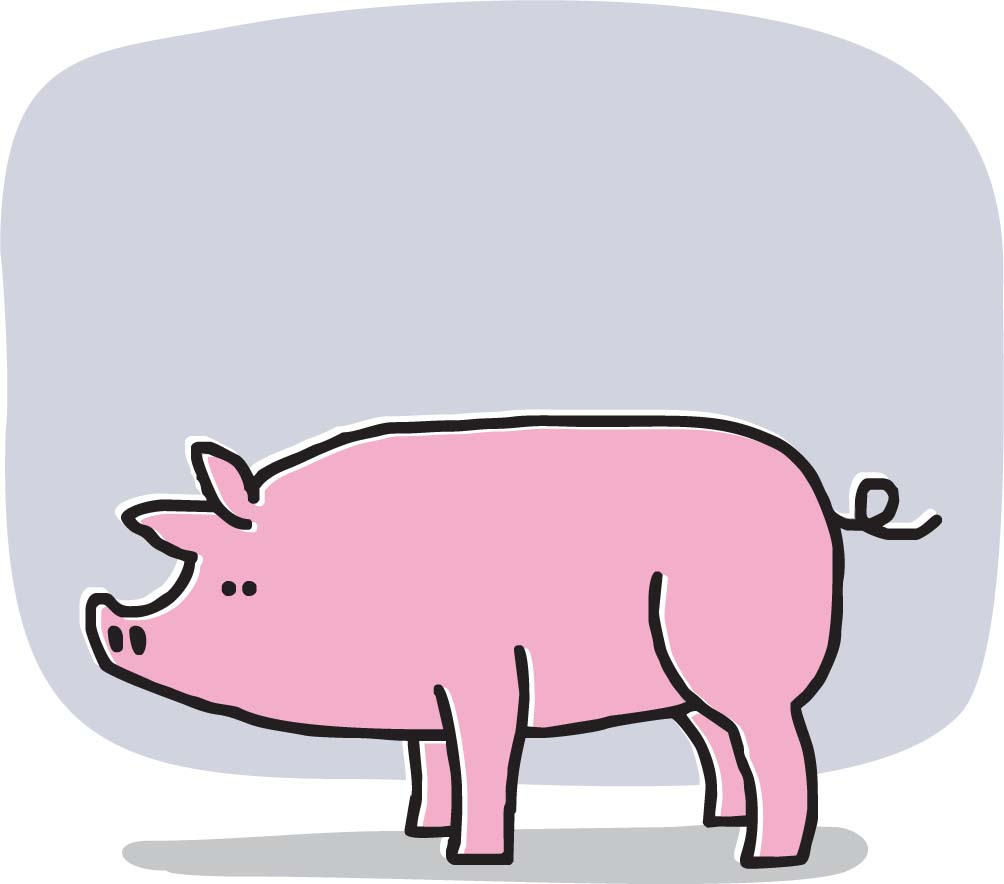

Four legs good, two legs bad.

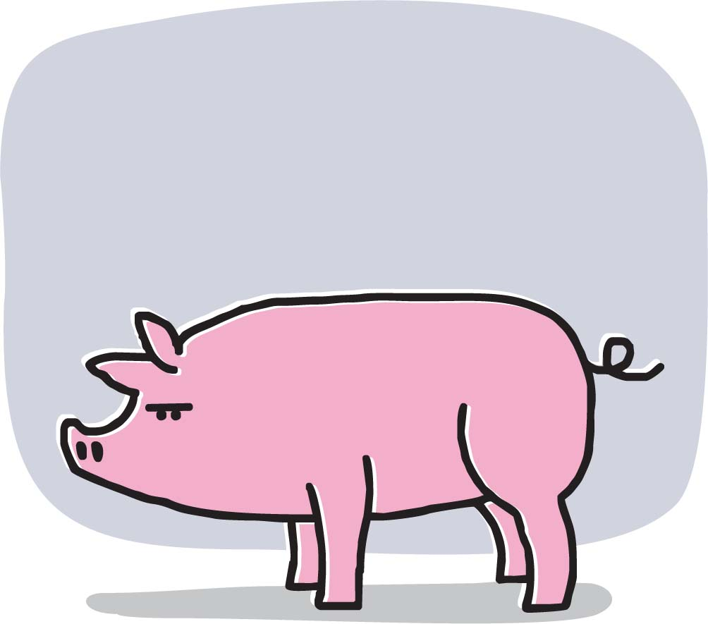

Then four legs bad.

Pride and Prejudice

Jane Austen

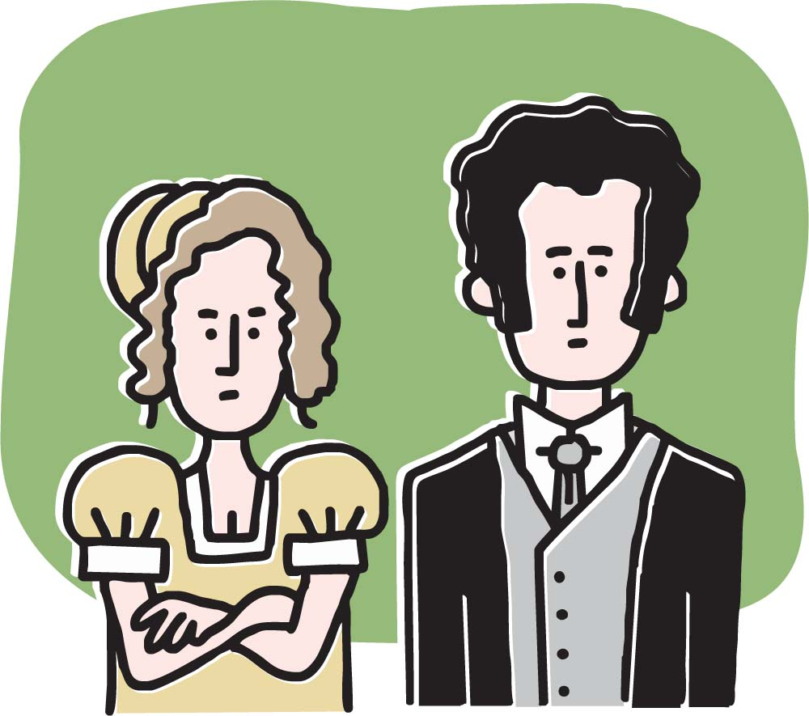

Girl hates wealthy aristocrat.

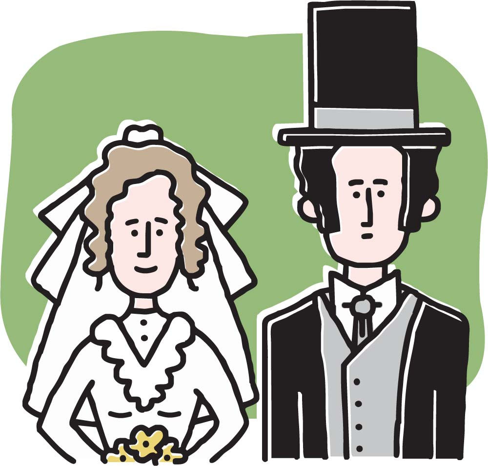

Wait, no she doesn’t.

The Odyssey

Homer

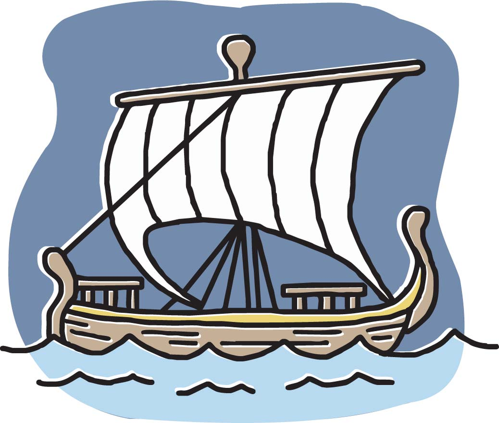

War veteran takes forever to get home, then kills everyone.

The Iliad

Homer

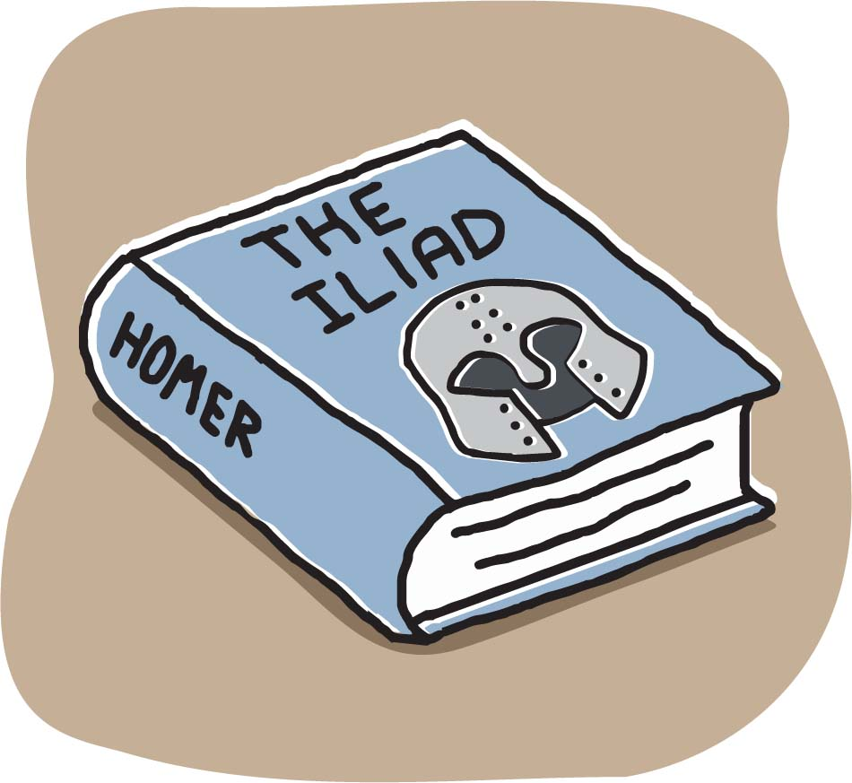

Not the Odyssey.

Don Quixote

Miguel de Cervantes

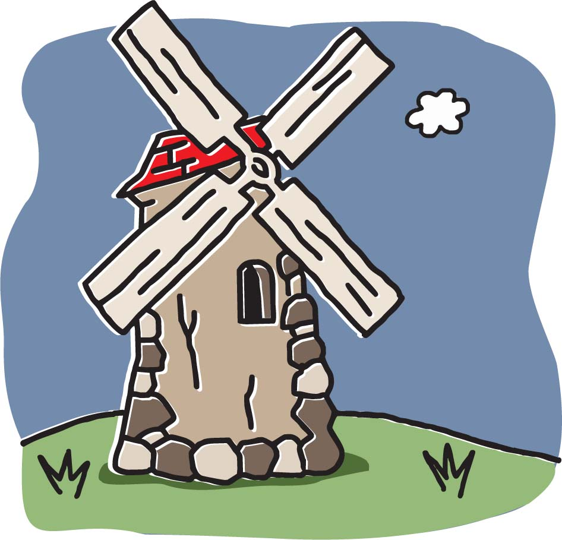

Guy attacks windmills.

[figure not shown]

Also, he’s mad.

Crime and Punishment

Fyodor Dostoyevsky

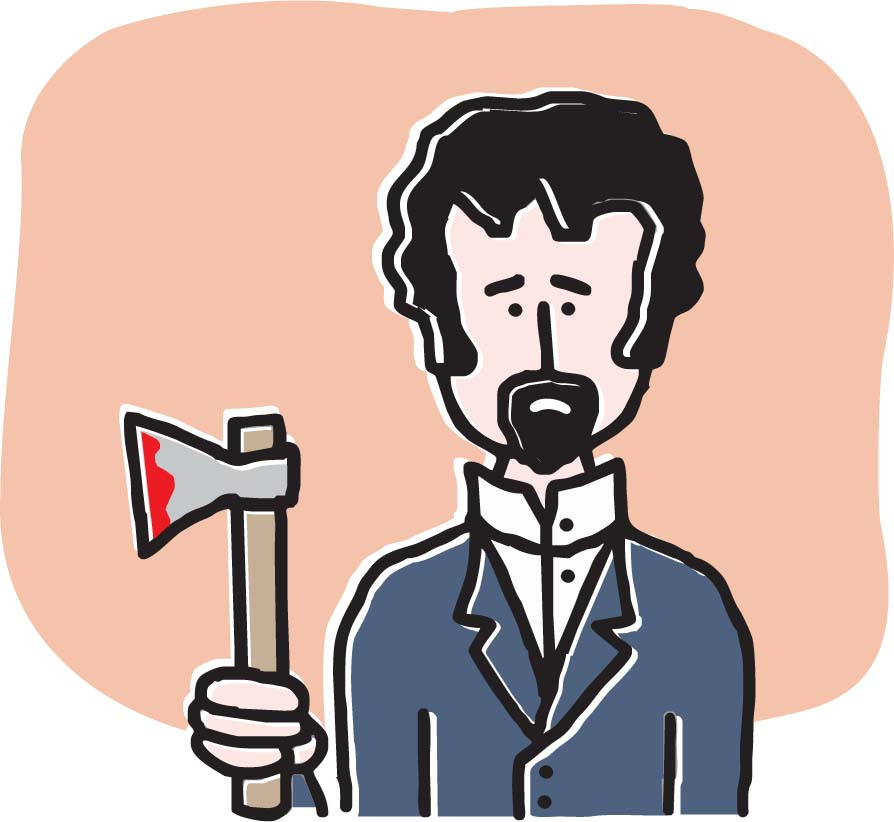

Murderer feels bad.

Confesses. Goes to jail.

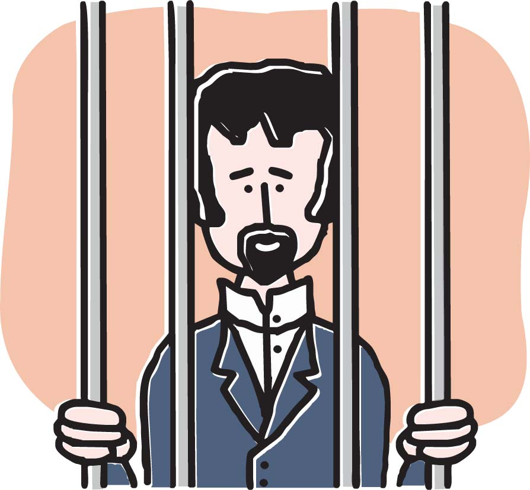

Feels better.

Catch-22

Joseph Heller

[figure not shown]

War is crazy, unless you are.

Orr maybe not.

Heart of Darkness

Joseph Conrad

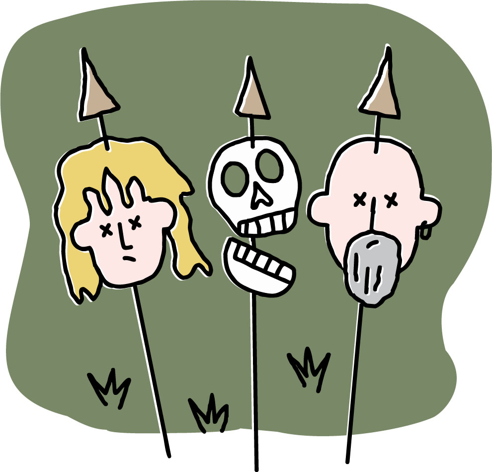

Colonialism ruins everything.

Also jungle metaphors.

The Republic

Plato

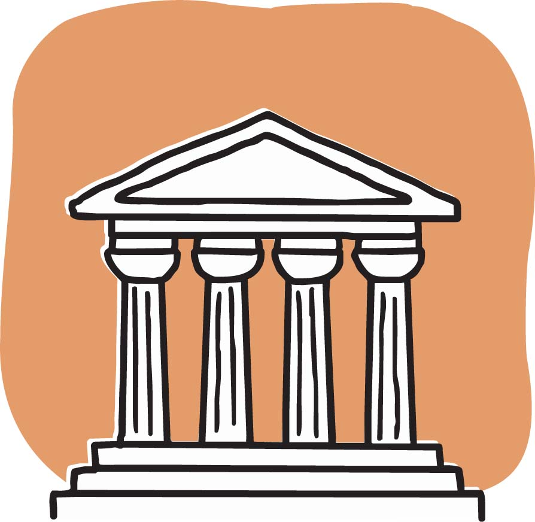

A really, really long city council meeting.

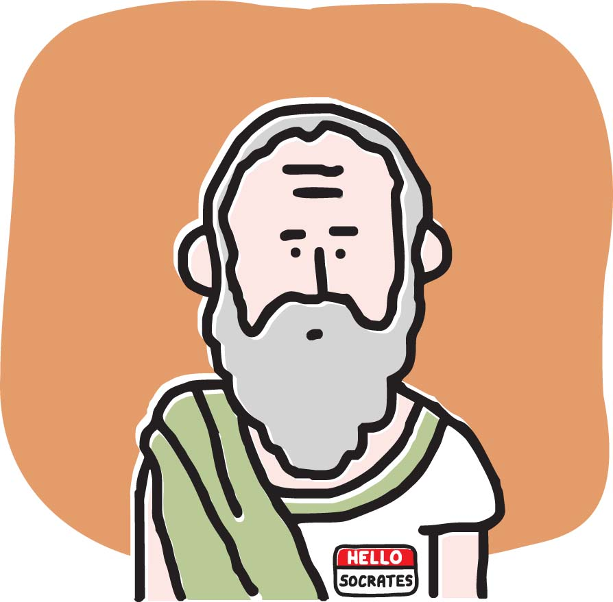

Socrates is there.

Wuthering Heights

Emily Brontë

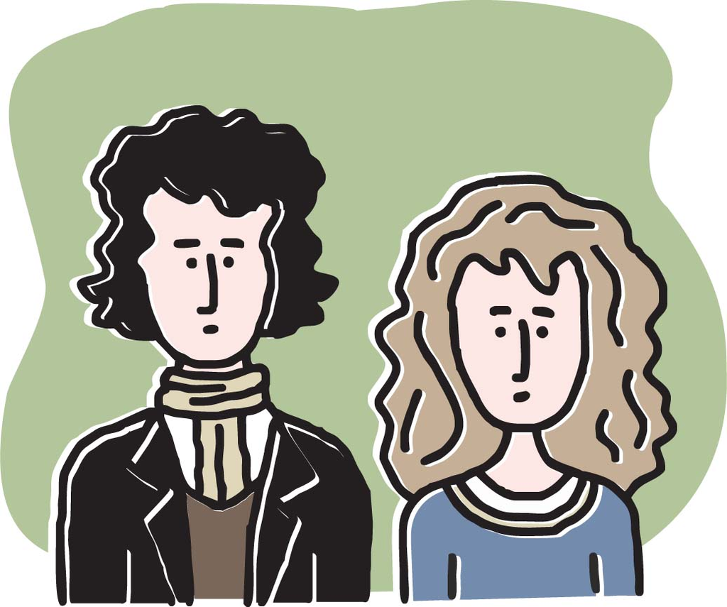

A sort-of brother and sister fall in love.

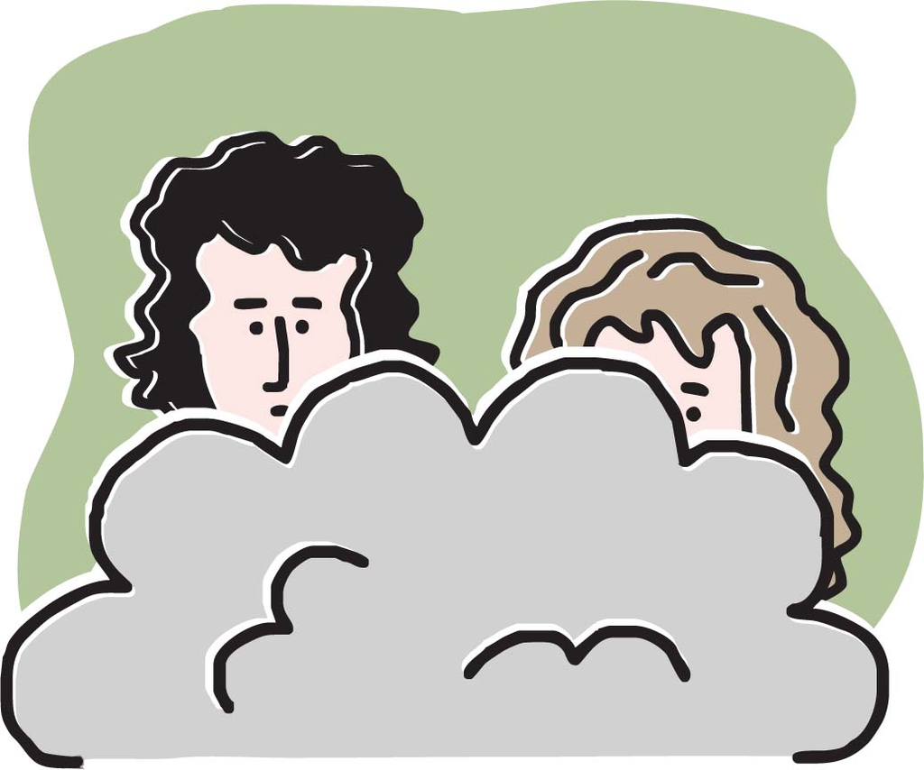

It’s foggy.

Robinson Crusoe

Daniel Defoe

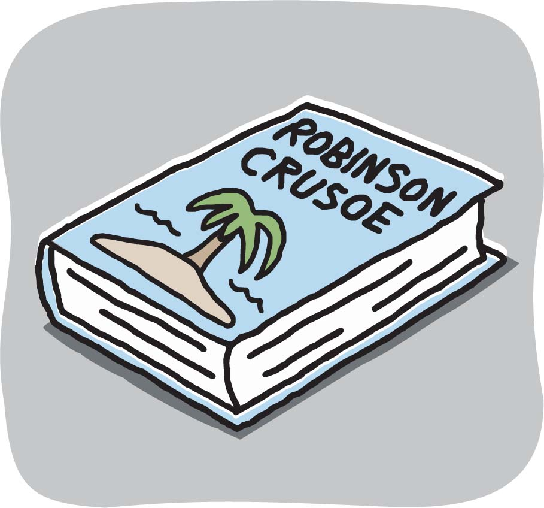

Old-timey Gilligan’s Island.

The Pearl

John Steinbeck

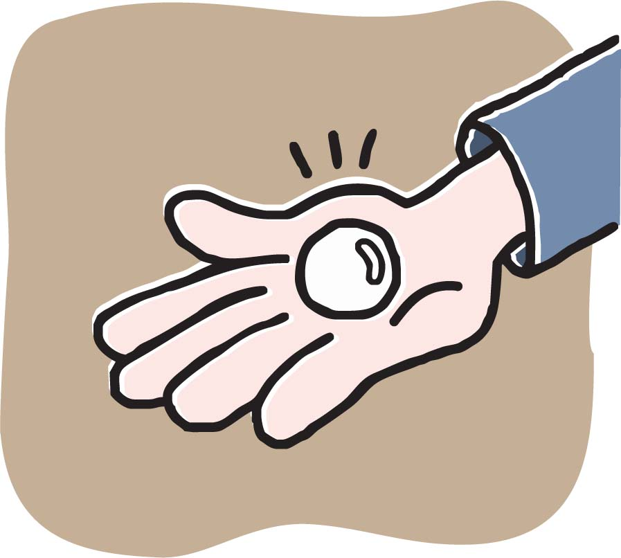

Owning stuff is problematic.

The Grapes of Wrath

John Steinbeck

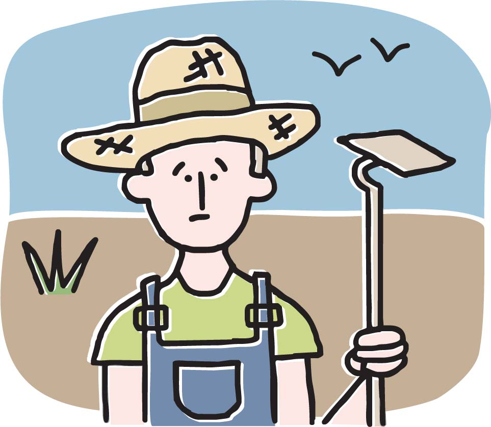

*Farming sucks. Road trip*!

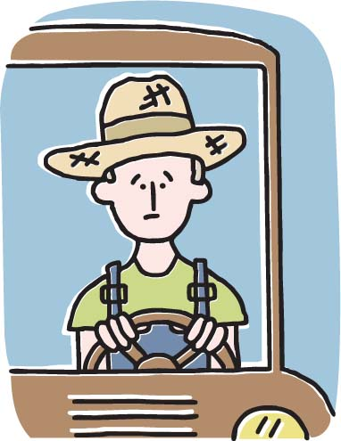

Road trip sucks.

A Farewell to Arms

Ernest Hemingway

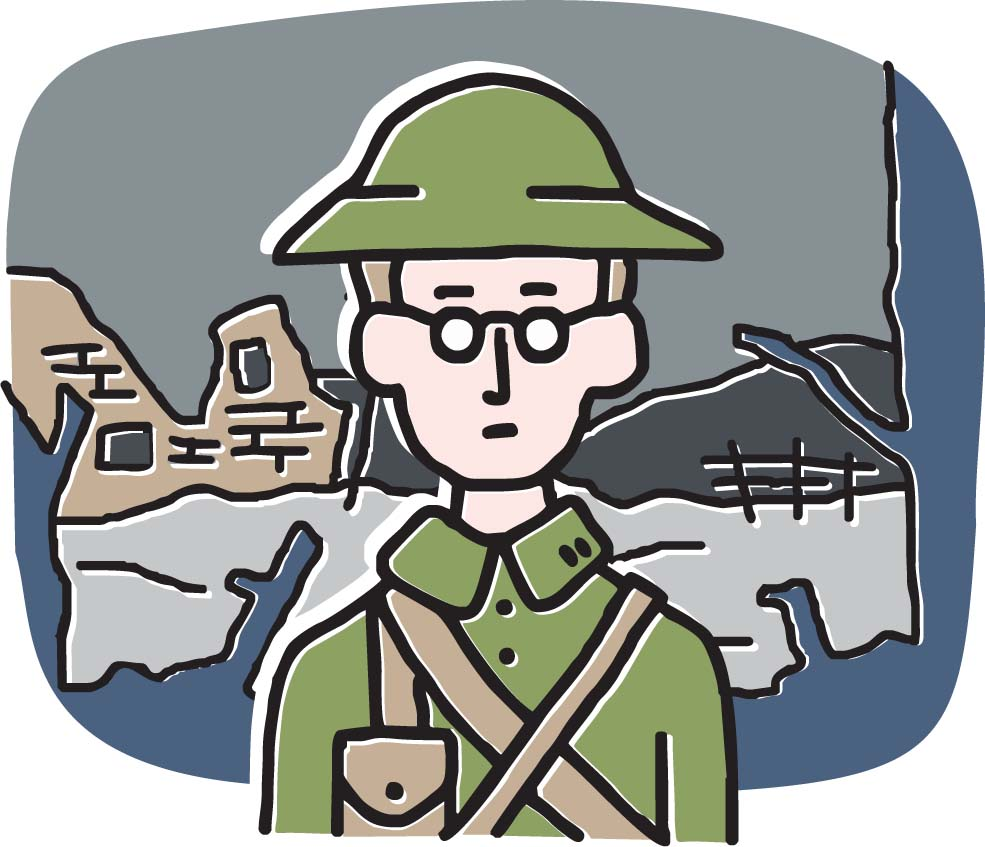

There are no winners in war.

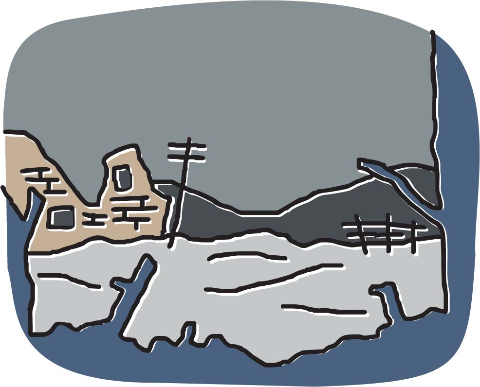

And very few adjectives.

The Rime of the Ancient Mariner

Samuel Taylor Coleridge

[figure not shown]

Old sailor kills a bird, then interrupts a wedding.

Othello

William Shakespeare

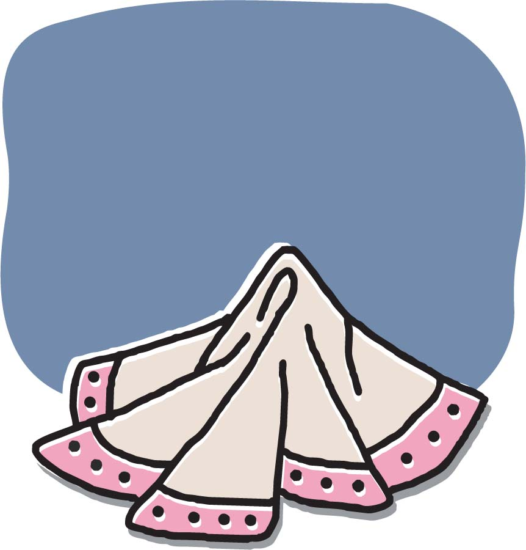

A lost hankie ruins everyone’s relationship.

On the Road

Jack Kerouac

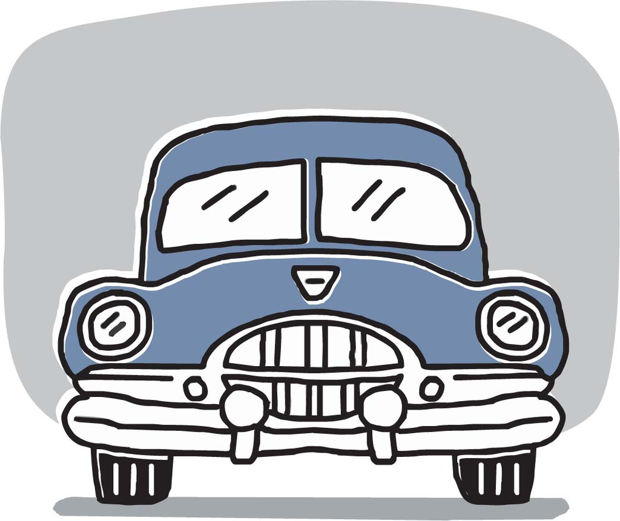

Post-war America is complicated and depressing.

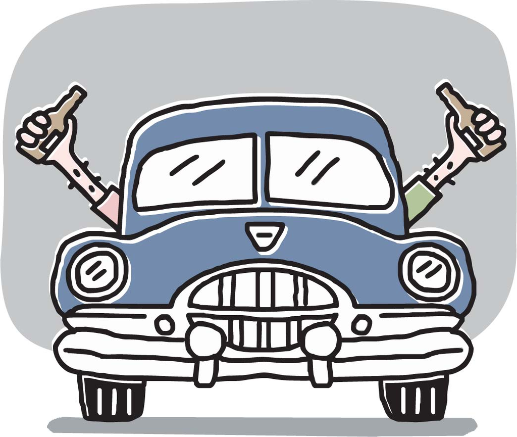

Booze helps.

The Canterbury Tales

Geoffrey Chaucer

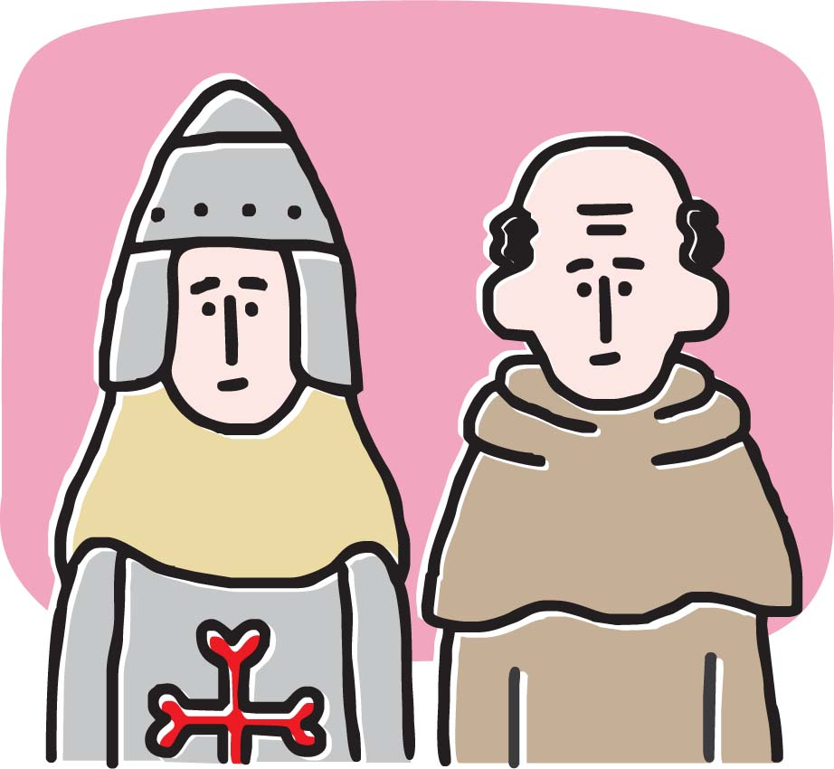

Medieval version of “99 Bottles of Beer.”

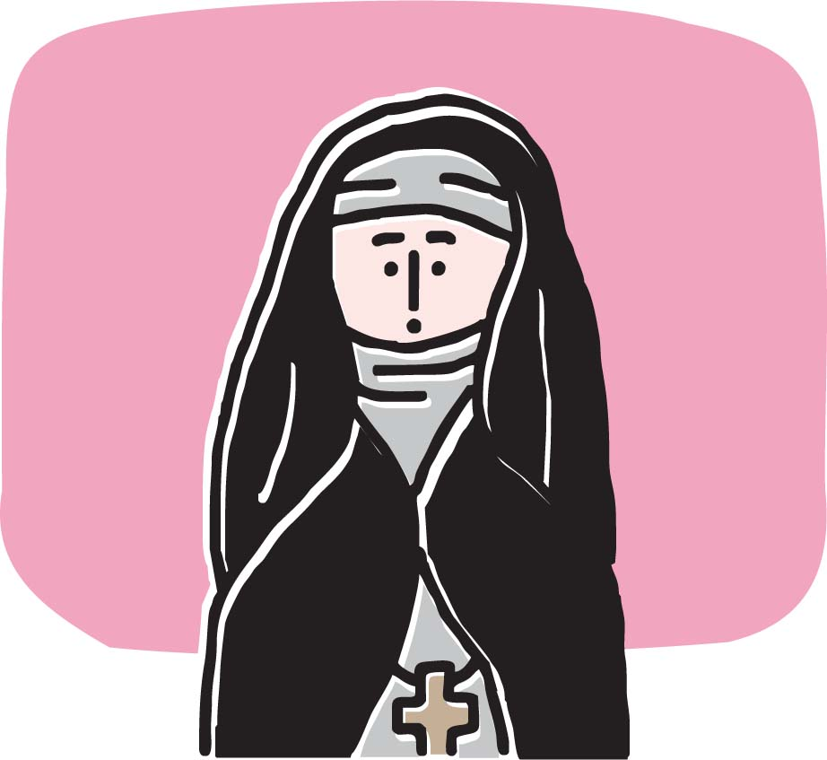

With sex and poop jokes.

The Divine Comedy: Inferno

Dante Alighieri

[figure not shown]

All hell breaks loose.

Peter Pan

J. M. Barrie

[figure not shown]

Some kids and a crocodile pester an amputee.

Treasure Island

Robert Louis Stevenson

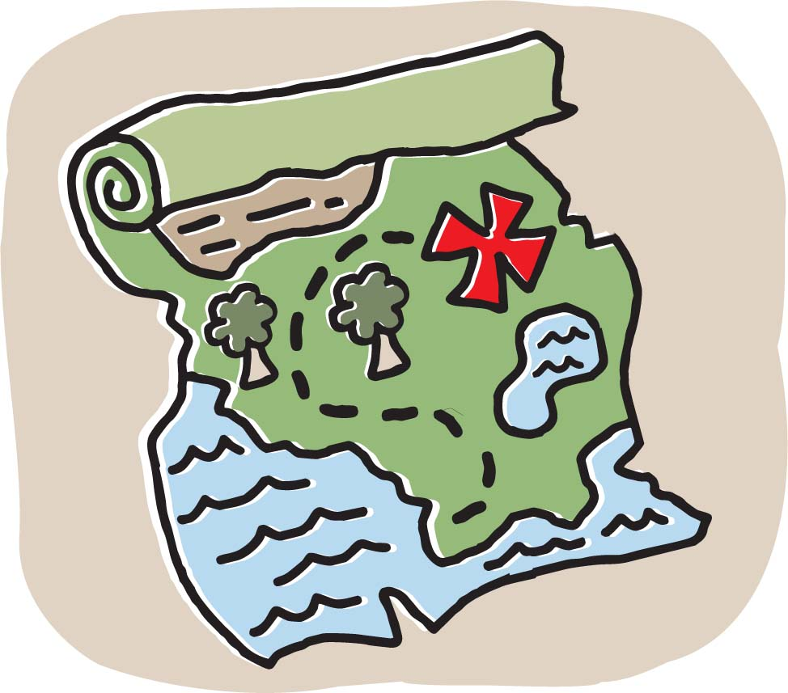

Booty hunt goes awry.

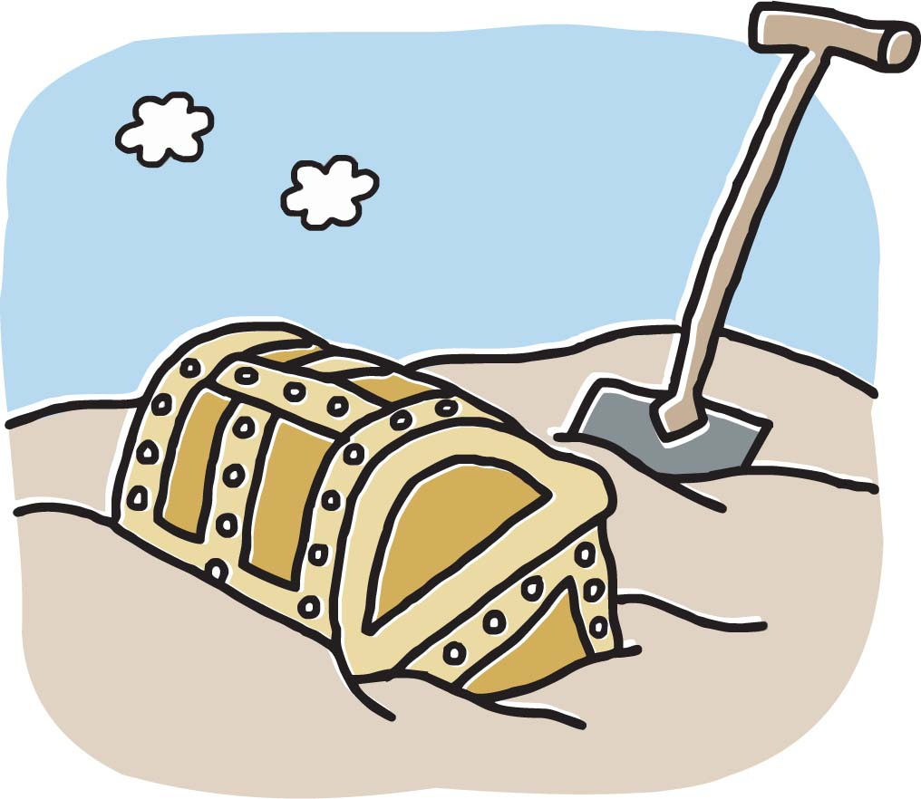

Then it doesn’t.

Then it does. Then it doesn’t.

Frankenstein

Mary Shelley

[figure not shown]

Monsters are people too.

[figure not shown]

Pieces of people.

Gulliver’s Travels

Jonathan Swift

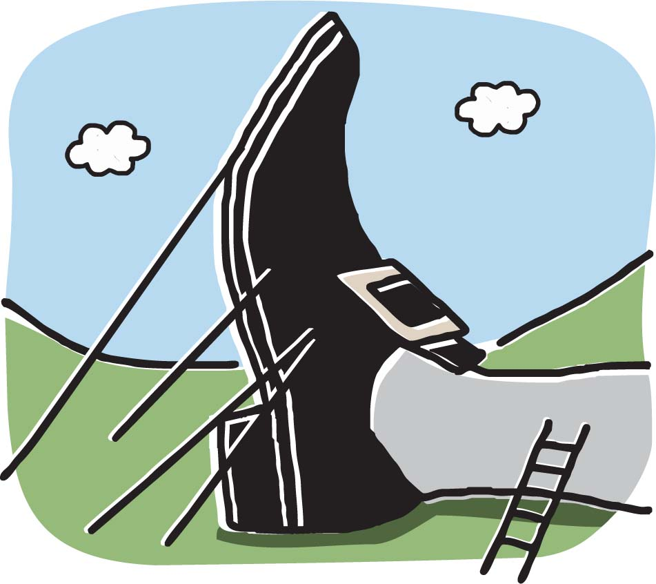

Hapless sailor is stranded on different lands inhabited by sociopolitical metaphors.

1984

George Orwell

[figure not shown]

*Vision of a dystopian future* (*now called Tuesday*).

Great Expectations

Charles Dickens

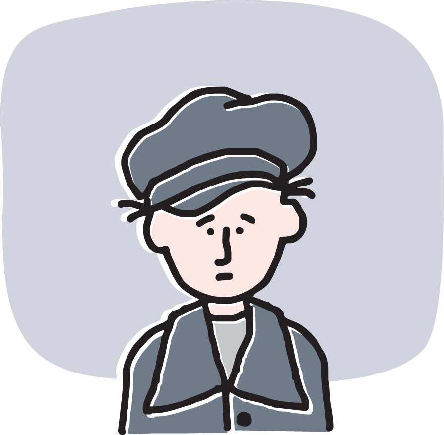

Poor boy’s benefactor is a crook.

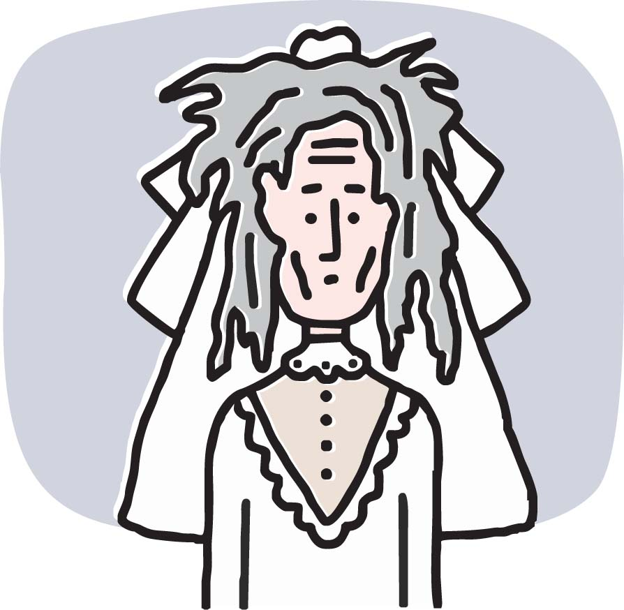

Old lady is no help at all.

The Adventures of Huckleberry Finn

Mark Twain

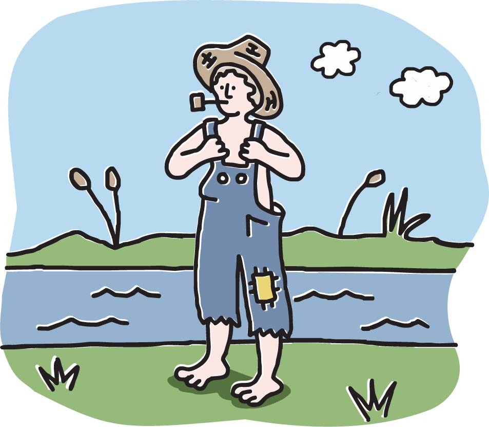

Kid takes a trip on a raft.

Hijinks ensue.

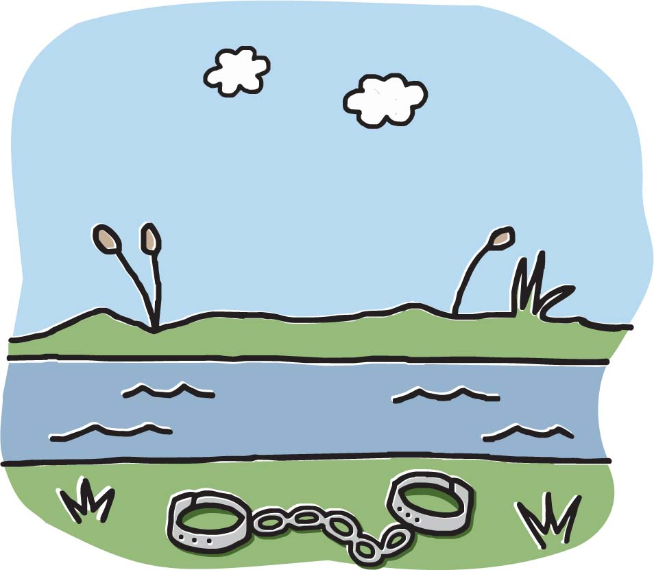

Also slavery.

The Aeneid

Virgil

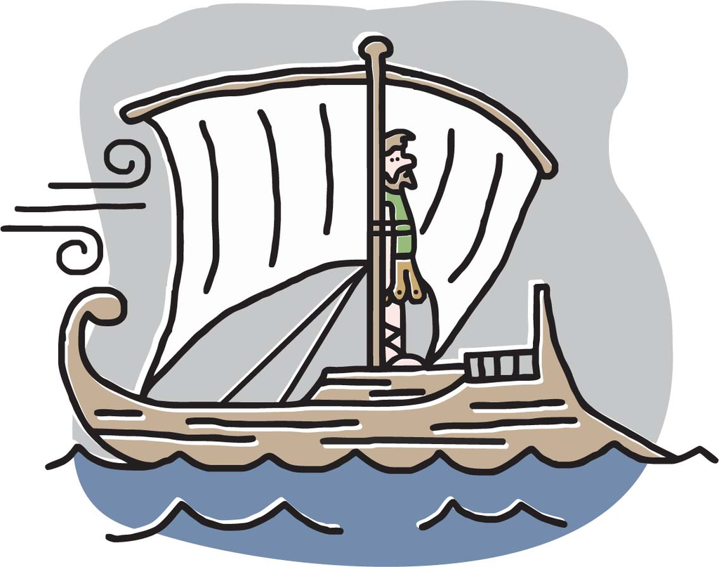

Angry gods make guy’s trip to Italy an epic ordeal.

The Return of the Native

Thomas Hardy

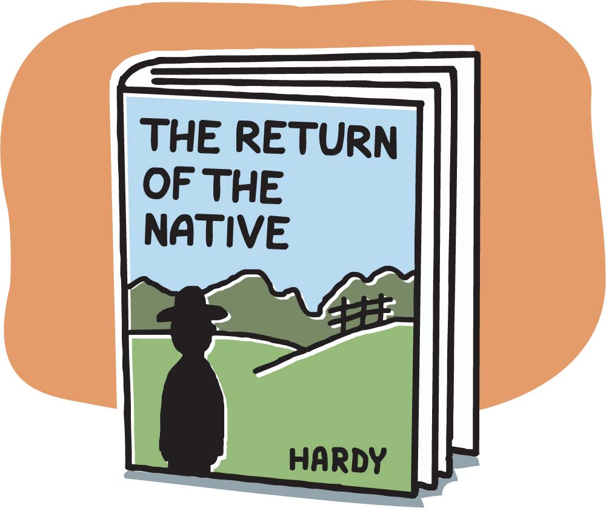

Local man comes home and ruins everything.

Sense and Sensibility

Jane Austen

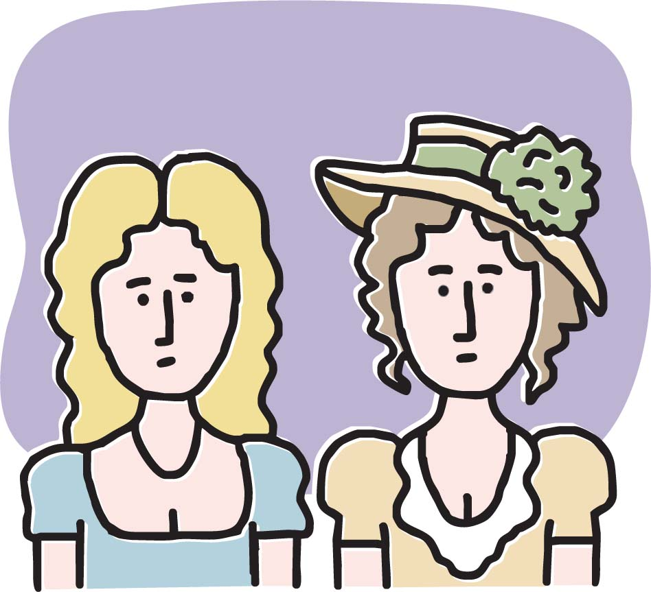

Two sisters catch husbands.

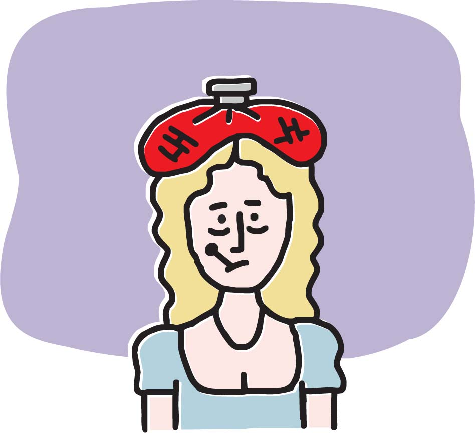

And one catches a cold.

The Trial

Franz Kafka

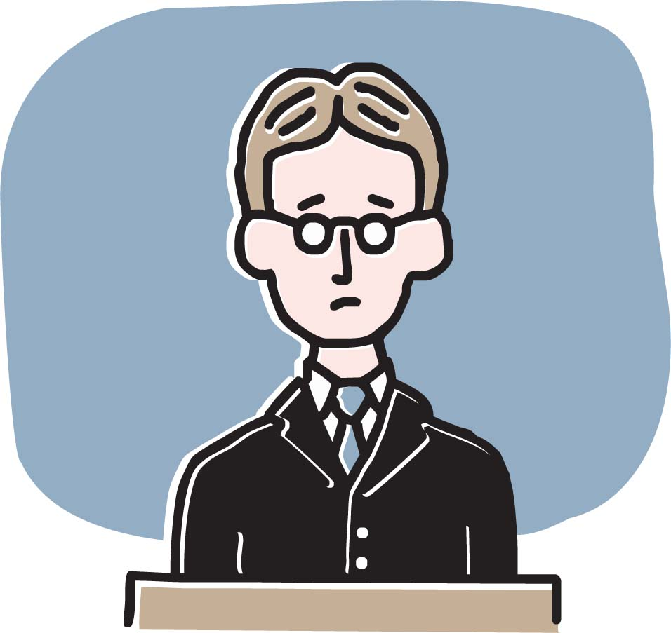

Guy is prosecuted.

No one knows why.

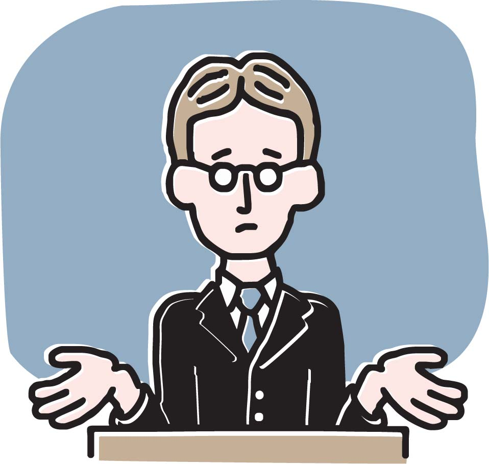

We don’t know why either.

Emma

Jane Austen

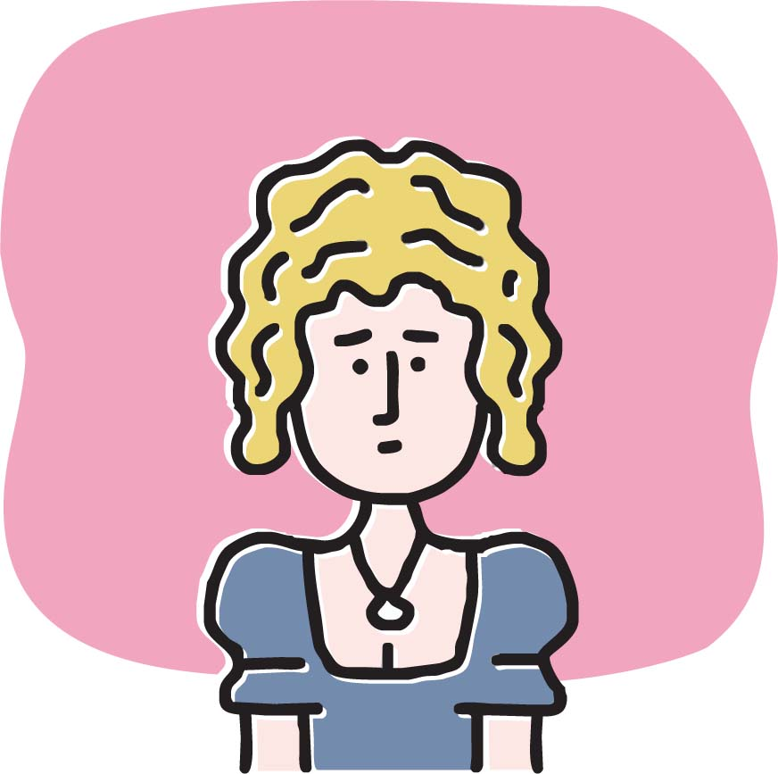

Busybody badgers everyone to get married.

The Lord of the Rings Trilogy

J. R. R. Tolkien

[figure not shown]

Middle-earth’s epic jewelry return policy.

The Great Gatsby

F. Scott Fitzgerald

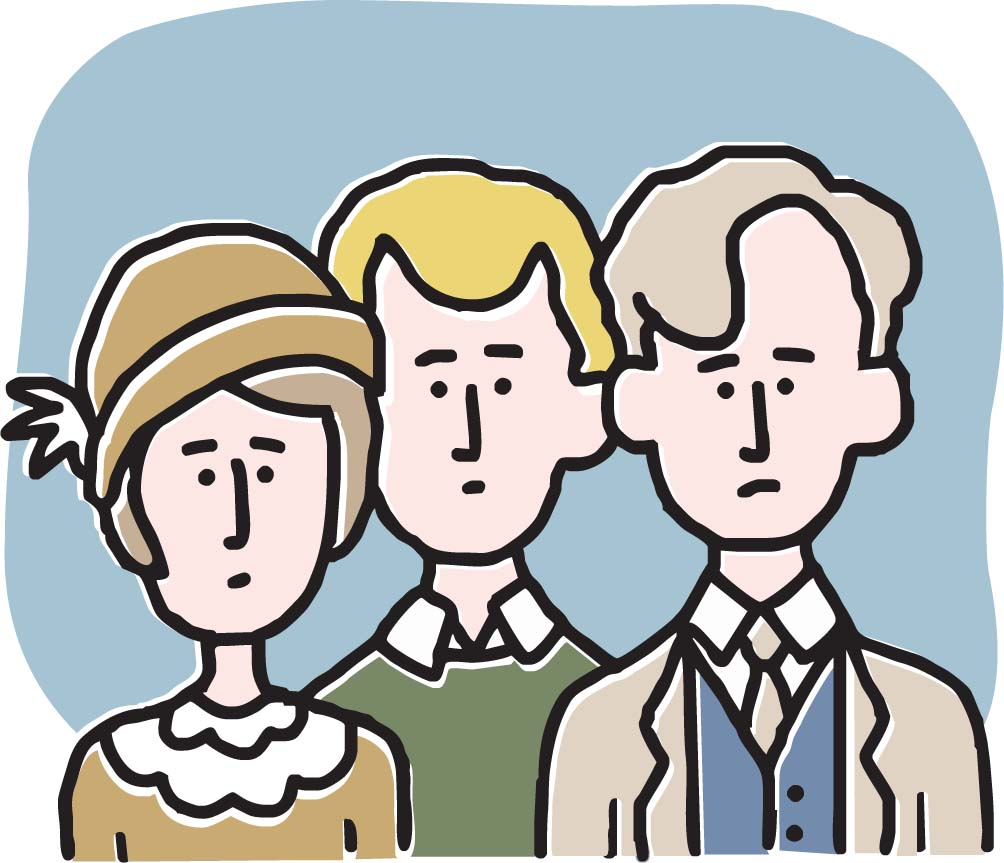

Rich, selfish people hang out.

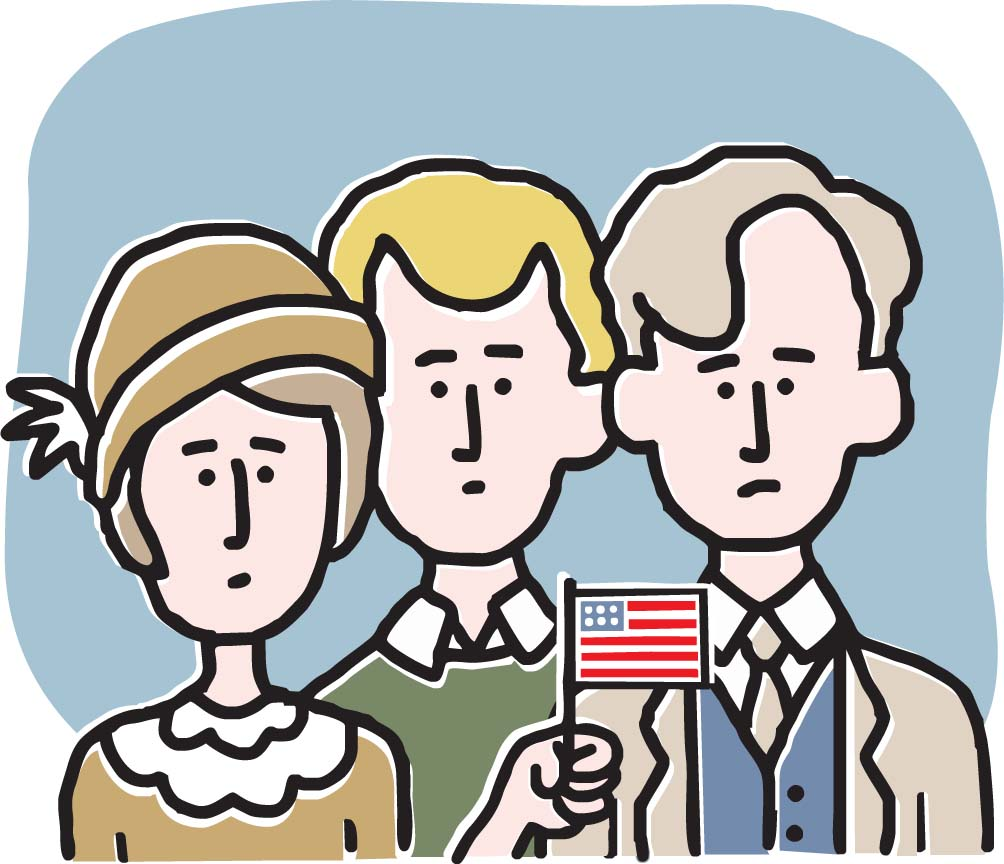

Something about the American dream.

King Lear

William Shakespeare

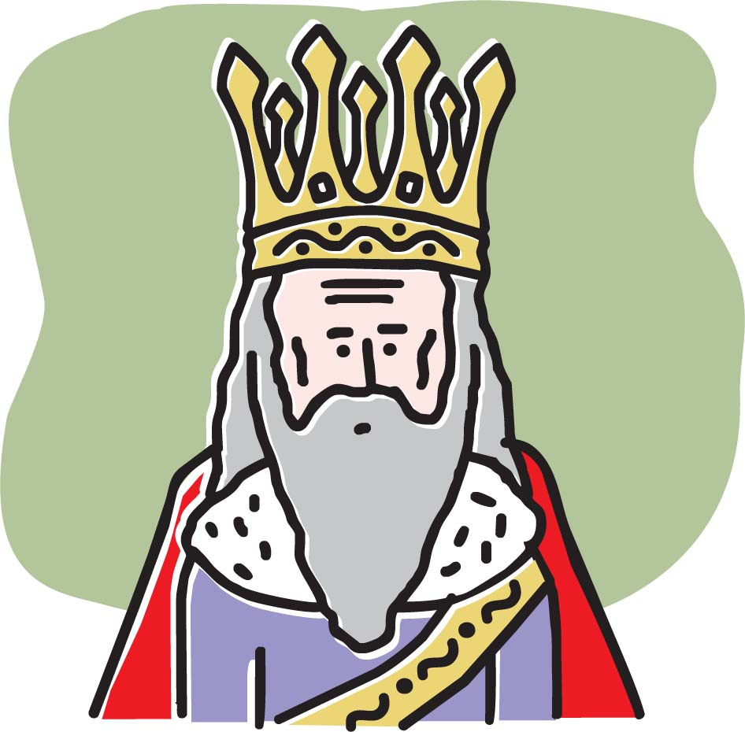

Old king goes mad.

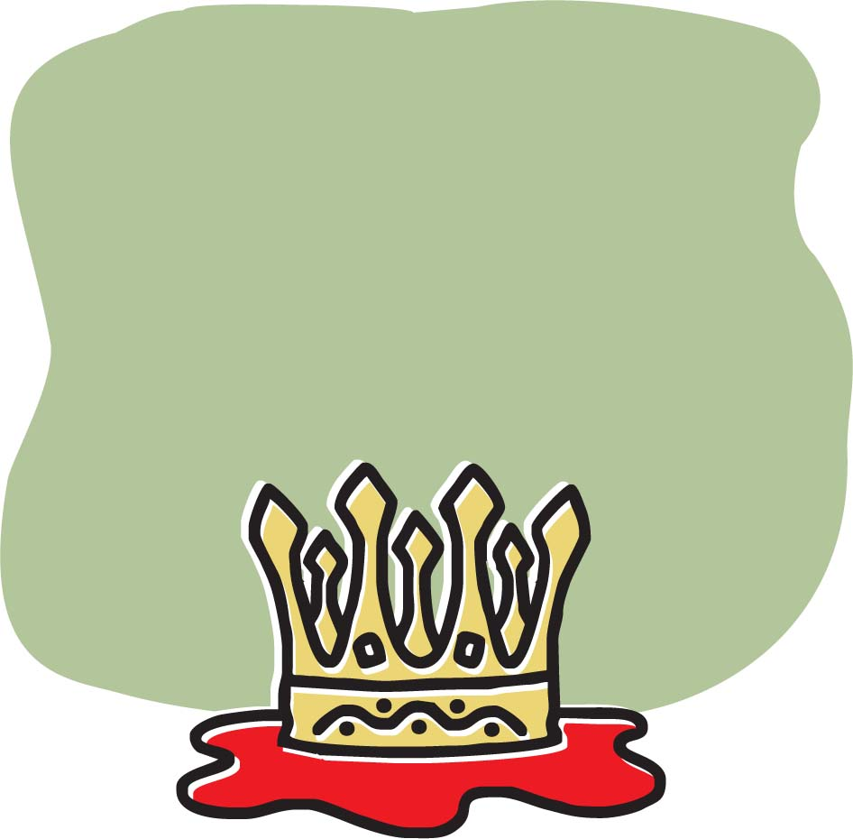

Everyone dies.

Ivanov

Anton Chekhov

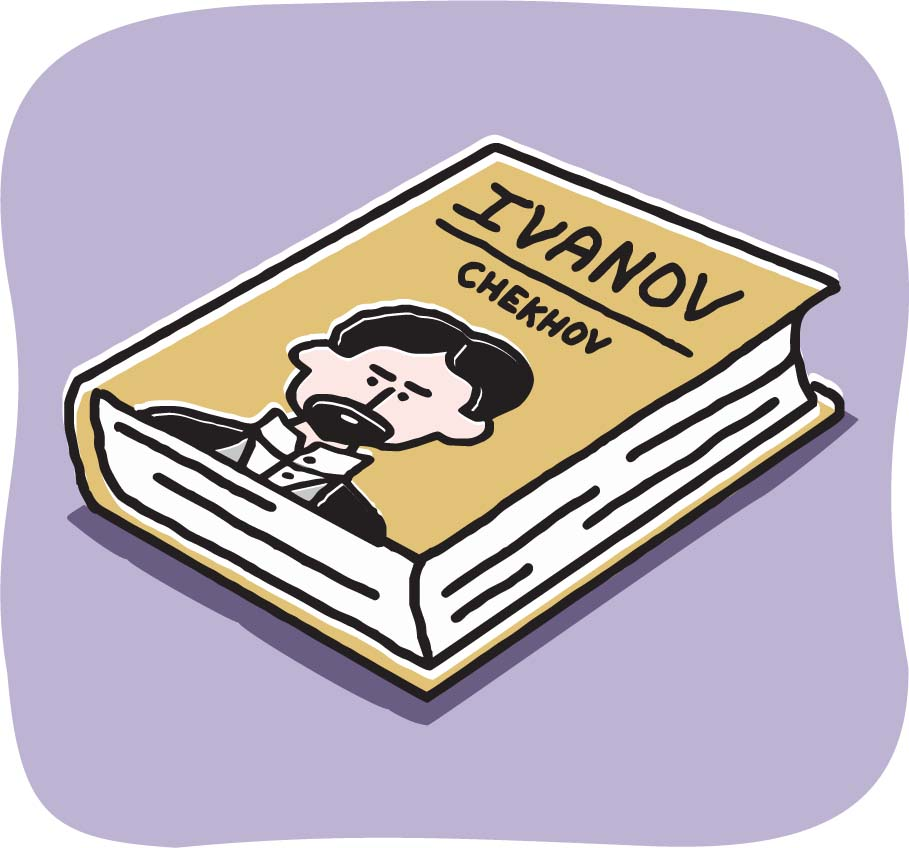

Guy hates everything.

Gets married. Kills himself.

The Crucible